# Filtering and merging

Chi Lam Poon

1/1/2020

Filter genes in a *tissue-aware* manner. Details see the YARN paper.

```r
suppressPackageStartupMessages({
  library(yarn)
  library(stringr)
  library(Biobase)
  library(dplyr)
  library(rafalib)
  library(readr)
  library(ggplot2)
  library(ggpubr)
  library(edgeR)
})
```

## Load data

```r
eset <- readRDS("~/cvd/v8/exprs/gtex.v8.rds")
dim(eset)
```

```
## Features  Samples
##    56200    17382
```

## Remove suboptimal samples

Those with `FLAGGED` in the `SMTORMVE` field were removed.

```r
table(pData(eset)$SMTORMVE)
```

```
##
##         FLAGGED
##   17382       0
```

Seems no `FLAGGED` sample in RNA-seq.

## Modify and filter subjects

Criteria:

1. MHCVD was recorded as value `0 (No)`, `1 (Yes)` and `99 (Unknown)`, therefore subjects with `0` or `1` were kept
2. Remove samples with `NA` Hardy scale values
3. Remove samples with `NA` ischemic time
4. Remove samples without batch info.

```r
# filter according to the criteria
sub.eset <- eset[, which((pData(eset)$MHCVD %in% c(0, 1)) &
                           (!is.na(pData(eset)$DTHHRDY)) &
                           (!is.na(pData(eset)$SMTSISCH)) &
                           (pData(eset)$SMNABTCHT != ""))]

dim(sub.eset); length(unique(pData(sub.eset)$SUBJID)); all(rownames(pData(sub.eset)) == colnames(exprs(sub.eset)))
```

```
## Features  Samples
##    56200    17182
```

```
## [1] 928
```

```
## [1] TRUE
```

```r
# # convert NA Hardy scale to 5
# pData(sub.eset)[is.na(pData(sub.eset)$DTHHRDY),]$DTHHRDY <- 5
```

## Remove unwanted tissues

Let’s see how many samples first.

```r
pdata <- pData(sub.eset)
pdata$MHCVD <- factor(pdata$MHCVD)

m_count1 <- pdata %>% group_by(MHCVD) %>% summarise(counts = n())
m_count2 <- pdata %>% group_by(SMTSD, MHCVD) %>% summarise(counts = n())
```

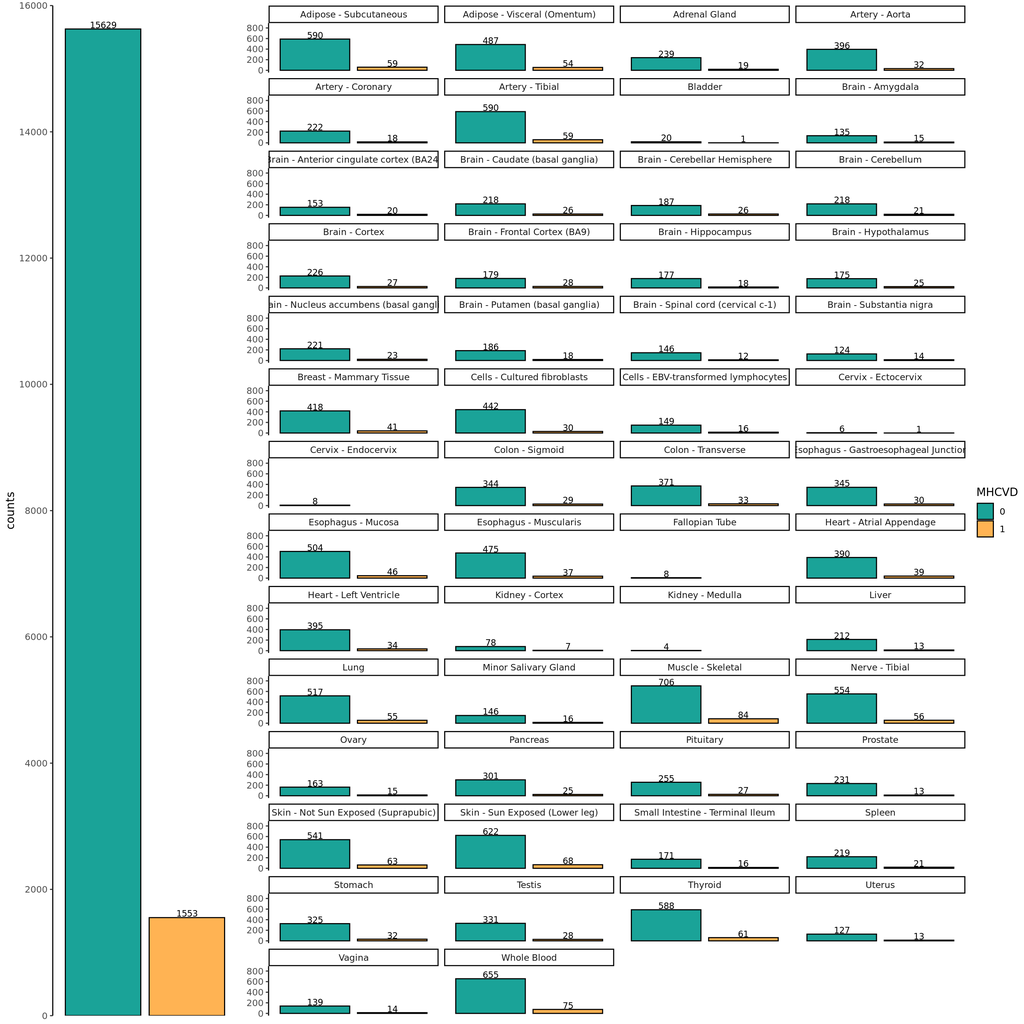

```r
# replace long names
# m_count2$our_subtypes <- gsub('adipose visceral \\(omentum\\)', 'adipose visceral', m_count2$our_subtypes)
# m_count2$our_subtypes <- gsub('esophagus gastroesophageal junction', 'gastroesophageal junction', m_count2$our_subtypes)
# m_count2$our_subtypes <- gsub('small intestine terminal ileum', 'intestine terminal ileum', m_count2$our_subtypes)

m1 <- ggplot(m_count1, aes(x=MHCVD, y=counts, fill=MHCVD)) +
  geom_bar(stat = "identity", color="black") +
  geom_text(aes(label=counts), vjust = -0.15, size = 3) +
  theme_classic() + theme(axis.title.x=element_blank()) +
  scale_fill_manual(values = c("#1aa398", "#ffb353")) +
  theme(axis.title.x=element_blank(),
        axis.text.x=element_blank(),
        axis.line.x=element_blank(),
        axis.ticks.x=element_blank()) +
  scale_y_continuous(limits=c(0,16000), breaks=seq(0,16000,by=2000), expand=c(0,0))

m2 <- ggplot(m_count2, aes(x=MHCVD, y=counts, fill=MHCVD)) +
  geom_bar(stat="identity", color="black") +
  geom_text(aes(label=counts), vjust = -0.1, size = 3) +
  theme_classic() +
  theme(axis.title.x=element_blank(),
        axis.text.x=element_blank(),
        axis.title.y=element_blank(),
        axis.line.x=element_blank(),
        axis.ticks.x=element_blank()) +
  scale_fill_manual(values = c("#1aa398", "#ffb353")) +
  scale_y_continuous(limits=c(0,850)) +
  facet_wrap(~SMTSD,ncol=4)

ggarrange(m1, m2, ncol=2, nrow=1, widths=c(1,3), common.legend = T, legend = "right")
```

- Cells - Cultured fibroblasts
- Cells - EBV-transformed lymphocytes
- Cells - Leukemia cell line (CML)
- Cervix - Ectocervix
- Cervix - Endocervix
- Bladder
- Fallopian Tube
- Kidney - Cortex
- Kidney - Medulla

```r
dim(sub.eset)
```

```
## Features  Samples
##    56200    17182
```

```r
throwTissues <- c('Cells - Cultured fibroblasts', 'Cells - EBV-transformed lymphocytes', 'Cells - Leukemia cell line (CML)', 'Cervix - Ectocervix', 'Cervix - Endocervix', 'Bladder', 'Fallopian Tube', 'Kidney - Cortex', 'Kidney - Medulla')

sub.eset2 <- sub.eset[, which(!pData(sub.eset)$SMTSD %in% throwTissues)]
dim(sub.eset2); all(rownames(pData(sub.eset2))==colnames(exprs(sub.eset2)))
```

```
## Features  Samples
##    56200    16412
```

```
## [1] TRUE
```

## Merge tissues

> We decided NOT to merge tissues in the new linear model.

The following tissues can be merge:

1. Skin
2. Skin - Not Sun Exposed (Suprapubic)
3. Skin - Sun Exposed (Lower leg)
4. Brain cerebellum
5. Brain - Cerebellum
6. Brain - Cerebellar Hemisphere
7. Brain basal ganglia
8. Brain - Caudate (basal ganglia)
9. Brain - Nucleus accumbens (basal ganglia)
10. Brain - Putamen (basal ganglia)
11. Brain cortex
12. Brain - Cortex
13. Brain - Frontal Cortex (BA9)
14. Brain - Anterior cingulate cortex (BA24)

```r
pData(sub.eset)$our_subtypes <- pData(sub.eset)$SMTSD
## skin
pData(sub.eset)$our_subtypes <- gsub('Skin - Not Sun Exposed \\(Suprapubic\\)', 'Skin', pData(sub.eset)$our_subtypes)
pData(sub.eset)$our_subtypes <- gsub('Skin - Sun Exposed \\(Lower leg\\)', 'Skin', pData(sub.eset)$our_subtypes)
## brain cerebellum
pData(sub.eset)$our_subtypes <- gsub('Brain - Cerebellar Hemisphere', 'Brain - Cerebellum', pData(sub.eset)$our_subtypes)
## brain basal ganglia
pData(sub.eset)$our_subtypes <- gsub('Brain - Caudate \\(basal ganglia\\)', 'Brain - Basal Ganglia', pData(sub.eset)$our_subtypes)
pData(sub.eset)$our_subtypes <- gsub('Brain - Nucleus accumbens \\(basal ganglia\\)', 'Brain - Basal Ganglia', pData(sub.eset)$our_subtypes)
pData(sub.eset)$our_subtypes <- gsub('Brain - Putamen \\(basal ganglia\\)', 'Brain - Basal Ganglia', pData(sub.eset)$our_subtypes)
## brain cortex
pData(sub.eset)$our_subtypes <- gsub('Brain - Frontal Cortex \\(BA9\\)', 'Brain - Cortex', pData(sub.eset)$our_subtypes)
pData(sub.eset)$our_subtypes <- gsub('Brain - Anterior cingulate cortex \\(BA24\\)', 'Brain - Cortex', pData(sub.eset)$our_subtypes)

pData(sub.eset)$our_subtypes <- gsub(' - ', ' ', pData(sub.eset)$our_subtypes)
pData(sub.eset)$our_subtypes <- gsub('\\s*\\([^\\)]+\\)', '', pData(sub.eset)$our_subtypes)

pData(sub.eset)$our_subtypes <- factor(pData(sub.eset)$our_subtypes)

# replace " - " & " "; turn into lower cases
pData(sub.eset)$our_subtypes <- tolower(pData(sub.eset)$our_subtypes)
pData(sub.eset)$our_subtypes <- gsub(" - ", "_", pData(sub.eset)$our_subtypes)
pData(sub.eset)$our_subtypes <- gsub(" ", "_", pData(sub.eset)$our_subtypes)
unique(pData(sub.eset)$our_subtypes)
```

[output not shown]

### View the samples again

MHCVD in v8!

```r
table(pData(sub.eset2)$MHCVD)
```

```
##
##     0     1
## 14914  1498
```

```r
pData(sub.eset2)$MHCVD <- factor(pData(sub.eset2)$MHCVD)

m_count1 <- pData(sub.eset2) %>% group_by(MHCVD) %>% summarise(counts = n())
m_count2 <- pData(sub.eset2) %>% group_by(SMTSD, MHCVD) %>% summarise(counts = n())
```

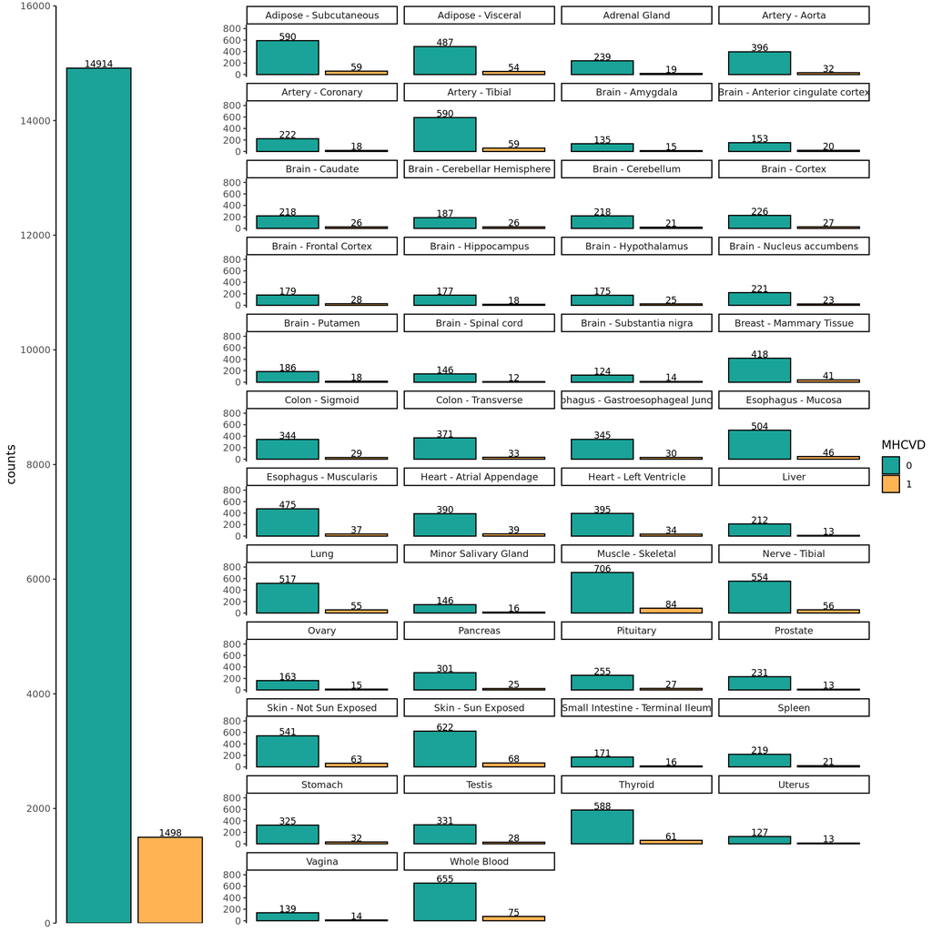

```r
# remove parentheses and contents within
m_count2$SMTSD <- gsub("\\s*\\([^\\)]+\\)", "", as.character(m_count2$SMTSD))

m1 <- ggplot(m_count1, aes(x=MHCVD, y=counts, fill=MHCVD)) +
  geom_bar(stat = "identity", color="black") +
  geom_text(aes(label=counts), vjust = -0.15, size = 3) +
  theme_classic() + theme(axis.title.x=element_blank()) +
  scale_fill_manual(values = c("#1aa398", "#ffb353")) +
  theme(axis.title.x=element_blank(),
        axis.text.x=element_blank(),
        axis.line.x=element_blank(),
        axis.ticks.x=element_blank()) +
  scale_y_continuous(limits=c(0,16000), breaks=seq(0,16000,by=2000), expand=c(0,0))

m2 <- ggplot(m_count2, aes(x=MHCVD, y=counts, fill=MHCVD)) +
  geom_bar(stat="identity", color="black") +
  geom_text(aes(label=counts), vjust = -0.1, size = 3) +
  theme_classic() +
  theme(axis.title.x=element_blank(),
        axis.text.x=element_blank(),
        axis.title.y=element_blank(),
        axis.line.x=element_blank(),
        axis.ticks.x=element_blank()) +
  scale_fill_manual(values = c("#1aa398", "#ffb353")) +
  scale_y_continuous(limits=c(0,830)) +
  facet_wrap(~SMTSD, ncol=4)

ggarrange(m1, m2, ncol=2, nrow=1, widths=c(1,3), common.legend = T, legend = "right")
```

## Filter genes

Need to filter out some lowly-expressed genes.

### Remove those were 0 across all samples

```r
for (i in 1:nrow(problems(exprs(sub.eset2)))) {
  exprs(sub.eset2)[problems(exprs(sub.eset2))$row[i], problems(exprs(sub.eset2))$col[i]] <- 1e+05
}
throwAway <- which(rowSums(exprs(sub.eset2)) == 0) # 326
sub.eset3 <- sub.eset2[-throwAway, ]
rm(sub.eset, sub.eset1, sub.eset2)
```

### Detele Y genes

```r
sub.eset4 <- sub.eset3[which(fData(sub.eset3)$chr != 'Y'),] # 500 genes
```

### Filter genes in a tissue-aware manner

Genes < 1 CPM in fewer than half of the number of samples of the smallest set of related samples are **out**.

```r
pData(sub.eset4)$SMTSD <- factor(pData(sub.eset4)$SMTSD)
minSamples <- min(table(pData(sub.eset4)$SMTSD))
minSamples <- floor(minSamples / 2) #69
counts <- cpm(exprs(sub.eset4))
keep <- rowSums(counts > 1) >= minSamples
sum(keep)
```

```
## [1] 29065
```

```r
sub.eset5 <- sub.eset4[keep,]
dim(sub.eset5)
```

```
## Features  Samples
##    29065    16412
```

```r
rm(sub.eset3, sub.eset4)
```

## Save data

```r
saveRDS(sub.eset5, file='~/cvd/v8/exprs/gtex.filted.rds')
```